# Name : Divya Pardeshi

# DATASET : 311_Customer_Service_Requests_Analysis

```python
#import library
import pandas as pd
import numpy as np
import matplotlib.pyplot as plt
import seaborn as sns
import datetime
%matplotlib inline
import warnings
warnings.filterwarnings("ignore")
```

```python
df1 = pd.read_csv('311_Service_Requests_from_2010_to_Present.csv')
```

## **Shape of the dataset**

```python
df1.shape
```

```
(364558, 53)
```

#### **Observation**:

- The 'dataset' has 364558 rows and 53 columns.

### **Print first 5 rows of the dataset**

```python
df1.head(5)
```

|  | Unique Key | Created Date | Closed Date | Agency | Agency Name | Complaint Type | Descriptor | Location Type | Incident Zip | Incident Address | ... | Bridge Highway Name | Bridge Highway Direction | Road Ramp | Bridge Highway Segment | Garage Lot Name | Ferry Direction | Ferry Terminal Name | Latitude | Longitude | Location |
| --- | --- | --- | --- | --- | --- | --- | --- | --- | --- | --- | --- | --- | --- | --- | --- | --- | --- | --- | --- | --- | --- |
| 0 | 32310363 | 12/31/2015 11:59:45 PM | 01/01/2016 12:55:15 AM | NYPD | New York City Police Department | Noise - Street/Sidewalk | Loud Music/Party | Street/Sidewalk | 10034.0 | 71 VERMILYEA AVENUE | ... | NaN | NaN | NaN | NaN | NaN | NaN | NaN | 40.865682 | -73.923501 | (40.86568153633767, -73.92350095571744) |
| 1 | 32309934 | 12/31/2015 11:59:44 PM | 01/01/2016 01:26:57 AM | NYPD | New York City Police Department | Blocked Driveway | No Access | Street/Sidewalk | 11105.0 | 27-07 23 AVENUE | ... | NaN | NaN | NaN | NaN | NaN | NaN | NaN | 40.775945 | -73.915094 | (40.775945312321085, -73.91509393898605) |
| 2 | 32309159 | 12/31/2015 11:59:29 PM | 01/01/2016 04:51:03 AM | NYPD | New York City Police Department | Blocked Driveway | No Access | Street/Sidewalk | 10458.0 | 2897 VALENTINE AVENUE | ... | NaN | NaN | NaN | NaN | NaN | NaN | NaN | 40.870325 | -73.888525 | (40.870324522111424, -73.88852464418646) |
| 3 | 32305098 | 12/31/2015 11:57:46 PM | 01/01/2016 07:43:13 AM | NYPD | New York City Police Department | Illegal Parking | Commercial Overnight Parking | Street/Sidewalk | 10461.0 | 2940 BAISLEY AVENUE | ... | NaN | NaN | NaN | NaN | NaN | NaN | NaN | 40.835994 | -73.828379 | (40.83599404683083, -73.82837939584206) |
| 4 | 32306529 | 12/31/2015 11:56:58 PM | 01/01/2016 03:24:42 AM | NYPD | New York City Police Department | Illegal Parking | Blocked Sidewalk | Street/Sidewalk | 11373.0 | 87-14 57 ROAD | ... | NaN | NaN | NaN | NaN | NaN | NaN | NaN | 40.733060 | -73.874170 | (40.733059618956815, -73.87416975810375) |

5 rows × 53 columns

#### **Observation**:

- The **'df1.head()'** function displays only the initial five rows of the dataset.

```python
# checking the info of the dataset
df1.info()
```

```
<class 'pandas.core.frame.DataFrame'>
RangeIndex: 364558 entries, 0 to 364557
Data columns (total 53 columns):
 #   Column                          Non-Null Count   Dtype
---  ------                          --------------   -----
 0   Unique Key                      364558 non-null  int64
 1   Created Date                    364558 non-null  object
 2   Closed Date                     362177 non-null  object
 3   Agency                          364558 non-null  object
 4   Agency Name                     364558 non-null  object
 5   Complaint Type                  364558 non-null  object
 6   Descriptor                      358057 non-null  object
 7   Location Type                   364425 non-null  object
 8   Incident Zip                    361560 non-null  float64
 9   Incident Address                312859 non-null  object
```

[output cut: 45 more lines]

```python
# viewing the columns
df1.columns
```

```
Index(['Unique Key', 'Created Date', 'Closed Date', 'Agency', 'Agency Name',
       'Complaint Type', 'Descriptor', 'Location Type', 'Incident Zip',
       'Incident Address', 'Street Name', 'Cross Street 1', 'Cross Street 2',
       'Intersection Street 1', 'Intersection Street 2', 'Address Type',
       'City', 'Landmark', 'Facility Type', 'Status', 'Due Date',
       'Resolution Description', 'Resolution Action Updated Date',
       'Community Board', 'Borough', 'X Coordinate (State Plane)',
       'Y Coordinate (State Plane)', 'Park Facility Name', 'Park Borough',
       'School Name', 'School Number', 'School Region', 'School Code',
       'School Phone Number', 'School Address', 'School City', 'School State',
       'School Zip', 'School Not Found', 'School or Citywide Complaint',
       'Vehicle Type', 'Taxi Company Borough', 'Taxi Pick Up Location',
       'Bridge Highway Name', 'Bridge Highway Direction', 'Road Ramp',
       'Bridge Highway Segment', 'Garage Lot Name', 'Ferry Direction',
       'Ferry Terminal Name', 'Latitude', 'Longitude', 'Location'],
      dtype='object')
```

#### **Observation:**

- Agency and Agency Name are more or less the same, so we can drop the same. Also,dropping other irrelevant columns which are not needed in our analysis.

```python
# dropping the irrelevant columns
df1.drop(['Agency Name','Incident Address','Street Name','Cross Street 1','Cross Street 2','Intersection Street 1',
'Intersection Street 2','Address Type','Park Facility Name','Park Borough','School Name',
'School Number','School Region','School Code','School Phone Number','School Address','School City',
'School State','School Zip','School Not Found','School or Citywide Complaint','Vehicle Type',
'Taxi Company Borough','Taxi Pick Up Location','Bridge Highway Name','Bridge Highway Direction',
'Road Ramp','Bridge Highway Segment','Garage Lot Name','Ferry Direction','Ferry Terminal Name','Landmark',
'X Coordinate (State Plane)','Y Coordinate (State Plane)','Due Date','Resolution Action Updated Date','Community Board','Facility Type'], axis = 1, inplace = True)
```

```python
# checking the shape of our dataset
df1.shape
```

```
(364558, 15)
```

#### **Observation**:

- Now, the 'dataset' has 364558 rows and 15 columns.

```python
# viewing the info to see the data types
df1.info()
```

```
<class 'pandas.core.frame.DataFrame'>
RangeIndex: 364558 entries, 0 to 364557
Data columns (total 15 columns):
 #   Column                  Non-Null Count   Dtype
---  ------                  --------------   -----
 0   Unique Key              364558 non-null  int64
 1   Created Date            364558 non-null  object
 2   Closed Date             362177 non-null  object
 3   Agency                  364558 non-null  object
 4   Complaint Type          364558 non-null  object
 5   Descriptor              358057 non-null  object
 6   Location Type           364425 non-null  object
 7   Incident Zip            361560 non-null  float64
 8   City                    361561 non-null  object
 9   Status                  364558 non-null  object
 10  Resolution Description  364558 non-null  object
 11  Borough                 364558 non-null  object
 12  Latitude                360528 non-null  float64
 13  Longitude               360528 non-null  float64
 14  Location                360528 non-null  object
dtypes: float64(3), int64(1), object(11)
memory usage: 41.7+ MB
```

#### **Observation**:

- The dataset have Created date and closed date columns which here is of object datatype. So we have to convert it into datetime format by using datetime module

```python
df1["Created Date"]=pd.to_datetime(df1['Created Date'])
df1["Closed Date"]=pd.to_datetime(df1['Closed Date'])
df1['Request_closing_time']=df1["Closed Date"]-df1["Created Date"]
```

## Check and manage the null values

```python
# checking the number of null values in the columns
df1.isna()
```

|  | Unique Key | Created Date | Closed Date | Agency | Complaint Type | Descriptor | Location Type | Incident Zip | City | Status | Resolution Description | Borough | Latitude | Longitude | Location | Request_closing_time |
| --- | --- | --- | --- | --- | --- | --- | --- | --- | --- | --- | --- | --- | --- | --- | --- | --- |
| 0 | False | False | False | False | False | False | False | False | False | False | False | False | False | False | False | False |
| 1 | False | False | False | False | False | False | False | False | False | False | False | False | False | False | False | False |
| 2 | False | False | False | False | False | False | False | False | False | False | False | False | False | False | False | False |
| 3 | False | False | False | False | False | False | False | False | False | False | False | False | False | False | False | False |
| 4 | False | False | False | False | False | False | False | False | False | False | False | False | False | False | False | False |
| ... | ... | ... | ... | ... | ... | ... | ... | ... | ... | ... | ... | ... | ... | ... | ... | ... |
| 364553 | False | False | False | False | False | False | False | False | False | False | False | False | False | False | False | False |
| 364554 | False | False | False | False | False | False | False | False | False | False | False | False | False | False | False | False |
| 364555 | False | False | False | False | False | False | False | False | False | False | False | False | False | False | False | False |
| 364556 | False | False | False | False | False | False | False | False | False | False | False | False | False | False | False | False |
| 364557 | False | False | False | False | False | False | False | False | False | False | False | False | False | False | False | False |

364558 rows × 16 columns

#### **Observation:**

- In a huge dataset, the code given above is not going to help
- We do not get enough idea of the null values by looking at the given tabular dataset
- The next line of code is more convenient in this case.

```python
# checking the number of sum of null values in the columns
df1.isna().sum(axis=0)
```

```
Unique Key                   0
Created Date                 0
Closed Date               2381
Agency                       0
Complaint Type               0
Descriptor                6501
Location Type              133
Incident Zip              2998
City                      2997
Status                       0
Resolution Description       0
Borough                      0
Latitude                  4030
Longitude                 4030
Location                  4030
Request_closing_time      2381
dtype: int64
```

#### **Observation:**

- We replace the null values with 'no info'

```python
df1['Closed Date'].fillna(value = 'no info', inplace = True)
```

```python
df1['Descriptor'].fillna(value = 'no info', inplace = True)
```

```python
df1['Location Type'].fillna(value = 'no info', inplace = True)
```

```python
df1['Incident Zip'].fillna(value = 'no info', inplace = True)
```

```python
df1['City'].fillna(value = 'no info', inplace = True)
```

```python
df1['Location'].fillna(value = 'no info', inplace = True)
```

```python
# checking again the number of sum of null values in the columns
df1.isna().sum(axis=0)
```

```
Unique Key                   0
Created Date                 0
Closed Date                  0
Agency                       0
Complaint Type               0
Descriptor                   0
Location Type                0
Incident Zip                 0
City                         0
Status                       0
Resolution Description       0
Borough                      0
Latitude                  4030
Longitude                 4030
Location                     0
Request_closing_time      2381
dtype: int64
```

#### **Observation:**

- Not replacing the null values of Latitude and longitude as it will be needed for data visualisation part and Request_closing_time will be needed for average response time calculation. So we are not replacing or dropping theses values from our dataset as we cannot afford to lose our datapoints.

```python
# plotting the complaint types
df1['Complaint Type'].value_counts()
```

```
Blocked Driveway             100881
Illegal Parking               92679
Noise - Street/Sidewalk       51692
Noise - Commercial            44109
Derelict Vehicle              21661
Noise - Vehicle               19352
Animal Abuse                  10541
Traffic                        5198
Homeless Encampment            4879
Vending                        4192
Noise - Park                   4109
Drinking                       1409
Noise - House of Worship       1070
Posting Advertisement           681
Urinating in Public             641
Bike/Roller/Skate Chronic       478
Panhandling                     327
Disorderly Youth                315
Illegal Fireworks               172
Graffiti                        157
Agency Issues                     8
Squeegee                          4
Ferry Complaint                   2
Animal in a Park                  1
Name: Complaint Type, dtype: int64
```

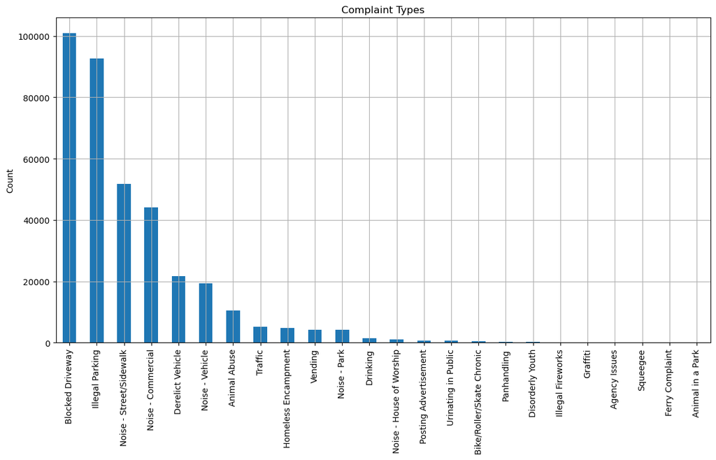

```python
df1['Complaint Type'].value_counts().plot(kind = 'bar', figsize=(14, 7), title='Complaint Types', ylabel='Count', grid=True)
```